Contents under Creative Commons BY 4.0 license and code under MIT license. © Julian Parra 2019. This material is part of the Master of Engineering program by Julian Parra at Universidad EAFIT.

# Two-dimensional base isolated frame.

This example discusses a simple base isolated two-dimensional frame under ground motion acceleration. The base isolation system is represented by non-linear rotational springs located between the column edges and the foundation system. The base acceleration is a Ricker pulse (see figure) applied along the horizontal direction.

[figure not shown]

The constitutive model for the non-linear spring is the one formulated in Simo and Hughes (2006) corresponding to a rate independent plasticity model with linear isotropic hardening. The non-inear springs at the base in this particular case provide rotational stiffness at the base of the first floor columns. This rotational stiffness is defined like:

\begin{array}{l}K_{loc}= \begin{bmatrix} \frac{4EI}{L} & \frac{-4EI}{L} \\ \frac{-4EI}{L} & \frac{4EI}{L} \end{bmatrix}\end{array}

where:

> - **$E$** = Material's young modulus.
> - **$I$** = Column's base moment of inertia along "Z" axis.
> - **$L$** = Column's lenght.

**Input and output files for this problem are available in the examples folder of this REPO (notebooks\Examples).**

Units for this example are **[kgf-m]**.

The main problem parameters are described next.

> - Ground acceleration signal: *Ricker pulse*
> - Ricker's central time, *Tc = 1.5 sec*
> - Ricker's central frequency, *fc = 1.5 Hz*
> - Maximum acceleration value: *1.0 g*
> - Time step for the input excitation: *0.002 sec*
> - Size if the analysis time window: *15.0 sec*
> - Element type for frame elements: `2`
> - Element type for nonlinear 1D rotational springs: `8`
> - Cross section for all the elements: *0.60 m x 0.60 m*
> - Material profile for the frame elements withelastic modulus of *500000 kgf/m²* and specific weight of *2000 kgf/m³*
> - Material profile for the rotational springs with an elastic modulus, **$E$** = *100000 kgf/m²*, yield strees, **$\sigma_{y}$** = *2000 kgf/m²* and isotropic hardening parameter, $K$ = *15000 tonf/m²*.

```python
%matplotlib inline
import matplotlib.pyplot as plt
import numpy as np
import sympy as sym
from os import sys
sys.path.append("../source/")
from STRUCTURE import Struct_DYN
from postprocesor import *

# Execute analysis
displacement,folder,IBC,nodes,elements,ninc,T,MvarsGen,ILFGen = Struct_DYN("Examples/Ex_05/01_INPUT/")
```

```
----------------------
Number of nodes: 6
Number of elements: 5
Number of equations: 8
Number of equations after constraints: 8
----------------------
Natural periods of the system :  [3.95578795 1.21821887 0.98266225 0.60780604 0.58275986 0.43858917
 0.43434444 0.39161916]
----------------------
Time step for solution: 0.002 sec
Number of time increments: 7500
----------------------
Finished initial conditions....: 0
Convergency reached after  1  iterations at increment  699  ( 1.398 sec)
Convergency reached after  1  iterations at increment  890  ( 1.78 sec)
Convergency reached after  1  iterations at increment  1085  ( 2.17 sec)
Convergency reached after  1  iterations at increment  1235  ( 2.47 sec)
Convergency reached after  1  iterations at increment  1991  ( 3.982 sec)
Convergency reached after  1  iterations at increment  2571  ( 5.142 sec)
Duration for system solution: 0:00:06.188326
Duration for the system's solution: 0:00:06.189336
Duration for post processing: 0:00:00
----------------------
Analysis terminated successfully!
----------------------
```

## Results

In a previous analysis the first 3 natural modes of the non-isolated building were found to be: **2.942 sec, 1.125 sec, 0.891 sec**.

On the other hand, the analysis shows that the rotational spring (element `0`) exhibits plastic behavior during the dynamic excitation.

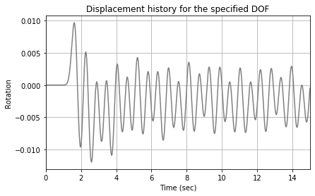

```python
fig = NodalDispPLT(displacement[0,:], T, ninc, ylabel = "Rotation")
```

Due to the inelastic response of the rotational spring the system now oscillates around a permanent deformed configuration. The Moment-curvature history for the rotational spring is shown below.

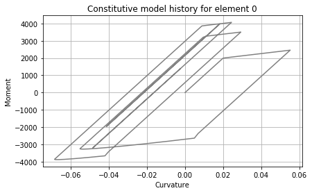

```python
histe = PlasModel(MvarsGen, Element = 0, xlabel = "Curvature", ylabel = "Moment")
```

### References

Simo, Juan C., and Thomas JR Hughes. Computational inelasticity. Vol. 7. Springer Science & Business Media, 2006

```python
from IPython.core.display import HTML
def css_styling():
    styles = open('./nb_style.css', 'r').read()
    return HTML(styles)
css_styling()
```